# Taller MonteCarlo

Beltran Henry, Burbano Joel,Guaman Ronny

Beltran Henry, Burbano Joel,Guamán Ronny

27/7/2021

# Ejercicios de fin de práctica

6. Aproximar mediante simulación la integral:
$$\int_{-1}^1 \frac{1}{8}(5-3x^2)dx$$

1. *Emplear integración Monte-Carlo clásica (distribución uniforme) y representar graficamente la aproximación en función de $n(1\leq n\leq 1000)$.*

Primero se describe el código de la función de Monte Carlo básica.

```r
mc.integral <- function(fun, a, b, n) {
    x <- runif(n, a, b)
    fx <- sapply(x, fun)
    return(mean(fx) * (b - a))
}



#Aunque posteriormente usaremos una función de Monte Carlo más compleja que incluye representación gráfica.


mc.integral <- function(fun, a, b, n, plot = TRUE) {
    fx <- sapply(runif(n, a, b), fun) * (b - a)
    if (plot) {
        estint <- cumsum(fx)/(1:n)
        esterr <- sqrt(cumsum((fx - estint)^2))/(1:n)
        plot(estint, ylab = "Media y rango de error", type = "l", lwd = 2, ylim = mean(fx) +
            2 * c(-esterr[1], esterr[1]), xlab = "Iteraciones")
        lines(estint + 2 * esterr, col = "darkgray", lwd = 2)
        lines(estint - 2 * esterr, col = "darkgray", lwd = 2)
        return(list(valor = estint[n], error = 2 * esterr[n]))
    } else return(list(valor = mean(fx), error = 2 * sd(fx)/sqrt(n)))
}
```

Escribrimos el código de la función objetivo y vamos a ver la aproximación por Montecarlo con un $n=20$ y $n=100$

**Con $n=20$, la aproximación es:**

```r
fun <- function(x) return((1/8) * (5-3*x^2))
set.seed(1718)
p1 <- mc.integral(fun, -1, 1, 20,plot = F)
p1$valor
```

```
## [1] 1.053105
```

**con $n=100$ la aproximaximación es:**

```r
p2 <- mc.integral(fun, -1, 1, 100,plot=F)
p2$valor
```

```
## [1] 0.9981363
```

En esta ocasión tenemos conocimiento del valor real de la integral, que es 1, así que comparándolo con el error real y el error obtenido mediante la función tenemos:

```
##       error_función error_por_aproximación
## n=20     0.08126175            0.053105500
## n=100    0.04783510            0.001863704
```

Notemos que el error dado por la función es MAYOR al error “real” obtenido mediante la integral exacta.

Ahora, realizamos una representación gráfica de la aproximación junto con los valores aproximados con $n=1000$

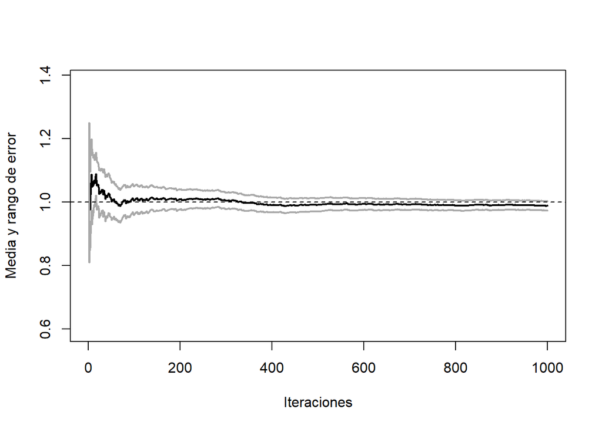

[figure not shown]

Y comparando también el error obtenido por la función con el error real tenemos:

```r
error_función <- c$error
error_por_aproximación <- abs(1-c$valor)
p <- cbind(error_función,error_por_aproximación)
row.names(p) <- c('n=1000')
p
```

```
##        error_función error_por_aproximación
## n=1000    0.01458013             0.01151994
```

Que al igual que en las otras $n$ simulaciones, se tiene que el error por función es mayor al valor real.

2. *Compara los resultados del apartado anterior con los obtenidos empleando muestreo de importancia con distribución auxiliar $N(0,0.3)$, ¿Se produce una reducción de la varianza?*

```r
set.seed(1718)
nsim <- 10^3
y <- rnorm(nsim,mean=0,sd=0.3)
w <- fun(y)/dnorm(y , sd=0.3)
```

Veamos la media obtenida en el intervalo $[-1,1]$

```r
mean(w * (y > -1) * (y < 1))
```

```
## [1] 1.041973
```

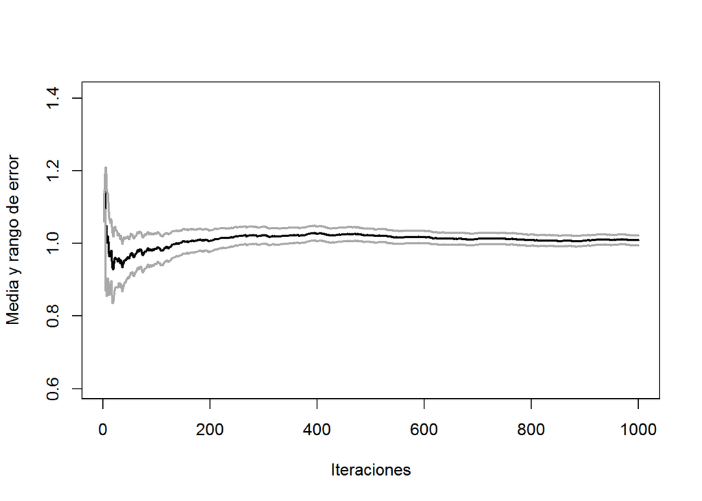

```r
#Esto es para obtener los datos del literal anterior.
mc.integral1 <- function(fun, a, b, n, plot = TRUE) {
    fx <- sapply(runif(n, a, b), fun) * (b - a)
    if (plot) {
        estint <- cumsum(fx)/(1:n)
        esterr <- sqrt(cumsum((fx - estint)^2))/(1:n)
        plot(estint, ylab = "Media y rango de error", type = "l", lwd = 2, ylim = mean(fx) +
            2 * c(-esterr[1], esterr[1]), xlab = "Iteraciones")
        lines(estint + 2 * esterr, col = "darkgray", lwd = 2)
        lines(estint - 2 * esterr, col = "darkgray", lwd = 2)
        return(estint)
    } else return(estint)
}
g <- mc.integral1(fun, -1, 1, 1000)
```

Comparemos ahora los datos obtenidos con este método y el literal anterior:

Podemos distiguir a la línea azul (los datos generados con el literal anterior) y con rojo los datos generados empleando muestreo de importancia.

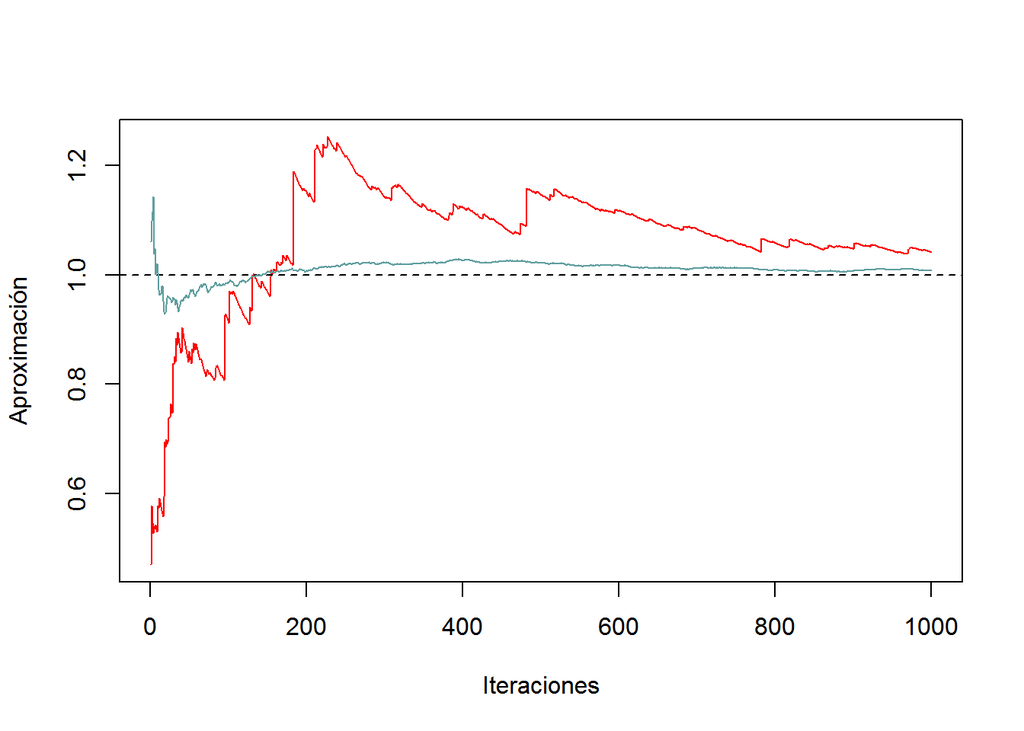

```r
plot(cumsum(w * (y > -1) * (y < 1))/1:nsim, type = "l", ylab = "Aproximación", xlab = "Iteraciones", col='red')
abline(h = 1, lty = 2)
lines(g,type = "l", ylab = "Aproximación", xlab = "Iteraciones",col='cadetblue')
```

```r
mean(w)
```

```
## [1] 1.162565
```

Si vemos el siguiente cáculo

```r
sqrt(var(w)/nsim)
```

```
## [1] 0.1061106
```

```r
sqrt(var(g)/nsim)
```

```
## [1] 0.0005456964
```

Se puede afirma que la varianza no se ha reducido con este método con respecto al del literal anterior.

3. *Generar 100 simulaciones de la distribución (aprox) con densidad $f(x)=\frac{1}{8}(5-3x^2)$ si $-1<x<1$ mediante remuestreo del muestro por importancia de 1000 valores de una $N(0,0.3)$*

```r
#Desarrolllo del literal c)
```

[output not shown]